# About

Here we will train a classifier to identify type of a particle. There are six particle types: electron, proton, muon, kaon, pion and ghost. Ghost is a particle with other type than the first five or a detector noise.

Different particle types remain different responses in the detector systems or subdetectors. Thre are five systems: tracking system, ring imaging Cherenkov detector (RICH), electromagnetic and hadron calorimeters, and muon system.

[figure not shown]

```python
%matplotlib inline
import matplotlib.pyplot as plt
import pandas
import numpy
from sklearn.model_selection import train_test_split
from sklearn.metrics import log_loss
import utils
```

### Read training file

```python
data = pandas.read_csv('training.csv.gz')
```

```python
data.head()
```

|  | TrackP | TrackNDoFSubdetector2 | BremDLLbeElectron | MuonLooseFlag | FlagSpd | SpdE | EcalDLLbeElectron | DLLmuon | RICHpFlagElectron | EcalDLLbeMuon | ... | TrackNDoF | RICHpFlagMuon | RICH_DLLbeKaon | RICH_DLLbeElectron | HcalE | MuonFlag | FlagMuon | PrsE | RICH_DLLbeMuon | RICH_DLLbeProton |
| --- | --- | --- | --- | --- | --- | --- | --- | --- | --- | --- | --- | --- | --- | --- | --- | --- | --- | --- | --- | --- | --- |
| 0 | 74791.156263 | 15.0 | 0.232275 | 1.0 | 1.0 | 3.2 | -2.505719 | 6.604153 | 1.0 | 1.929960 | ... | 28.0 | 1.0 | -7.213300 | -0.280200 | 5586.589846 | 1.0 | 1.0 | 10.422315 | -2.081143e-07 | -24.824400 |
| 1 | 2738.489989 | 15.0 | -0.357748 | 0.0 | 1.0 | 3.2 | 1.864351 | 0.263651 | 1.0 | -2.061959 | ... | 32.0 | 1.0 | -0.324317 | 1.707283 | -0.000007 | 0.0 | 1.0 | 43.334935 | 2.771583e+00 | -0.648017 |
| 2 | 2161.409908 | 17.0 | -999.000000 | 0.0 | 0.0 | -999.0 | -999.000000 | -999.000000 | 0.0 | -999.000000 | ... | 27.0 | 0.0 | -999.000000 | -999.000000 | -999.000000 | 0.0 | 0.0 | -999.000000 | -9.990000e+02 | -999.000000 |
| 3 | 15277.730490 | 20.0 | -0.638984 | 0.0 | 1.0 | 3.2 | -2.533918 | -8.724949 | 1.0 | -3.253981 | ... | 36.0 | 1.0 | -35.202221 | -14.742319 | 4482.803707 | 0.0 | 1.0 | 2.194175 | -3.070819e+00 | -29.291519 |
| 4 | 7563.700195 | 19.0 | -0.638962 | 0.0 | 1.0 | 3.2 | -2.087146 | -7.060422 | 1.0 | -0.995816 | ... | 33.0 | 1.0 | 25.084287 | -10.272412 | 5107.554680 | 0.0 | 1.0 | 0.000015 | -5.373712e+00 | 23.653087 |

5 rows × 50 columns

### List of columns in the samples

Here, **Spd** stands for Scintillating Pad Detector, **Prs** - Preshower, **Ecal** - electromagnetic calorimeter, **Hcal** - hadronic calorimeter, **Brem** denotes traces of the particles that were deflected by detector.

- ID - id value for tracks (presents only in the test file for the submitting purposes)
- Label - string valued observable denoting particle types. Can take values "Electron", "Muon", "Kaon", "Proton", "Pion" and "Ghost". This column is absent in the test file.
- FlagSpd - flag (0 or 1), if reconstructed track passes through Spd
- FlagPrs - flag (0 or 1), if reconstructed track passes through Prs
- FlagBrem - flag (0 or 1), if reconstructed track passes through Brem
- FlagEcal - flag (0 or 1), if reconstructed track passes through Ecal
- FlagHcal - flag (0 or 1), if reconstructed track passes through Hcal
- FlagRICH1 - flag (0 or 1), if reconstructed track passes through the first RICH detector
- FlagRICH2 - flag (0 or 1), if reconstructed track passes through the second RICH detector
- FlagMuon - flag (0 or 1), if reconstructed track passes through muon stations (Muon)
- SpdE - energy deposit associated to the track in the Spd
- PrsE - energy deposit associated to the track in the Prs
- EcalE - energy deposit associated to the track in the Hcal
- HcalE - energy deposit associated to the track in the Hcal
- PrsDLLbeElectron - delta log-likelihood for a particle candidate to be electron using information from Prs
- BremDLLbeElectron - delta log-likelihood for a particle candidate to be electron using information from Brem
- TrackP - particle momentum
- TrackPt - particle transverse momentum
- TrackNDoFSubdetector1 - number of degrees of freedom for track fit using hits in the tracking sub-detector1
- TrackQualitySubdetector1 - chi2 quality of the track fit using hits in the tracking sub-detector1
- TrackNDoFSubdetector2 - number of degrees of freedom for track fit using hits in the tracking sub-detector2
- TrackQualitySubdetector2 - chi2 quality of the track fit using hits in the tracking sub-detector2
- TrackNDoF - number of degrees of freedom for track fit using hits in all tracking sub-detectors
- TrackQualityPerNDoF - chi2 quality of the track fit per degree of freedom
- TrackDistanceToZ - distance between track and z-axis (beam axis)
- Calo2dFitQuality - quality of the 2d fit of the clusters in the calorimeter
- Calo3dFitQuality - quality of the 3d fit in the calorimeter with assumption that particle was electron
- EcalDLLbeElectron - delta log-likelihood for a particle candidate to be electron using information from Ecal
- EcalDLLbeMuon - delta log-likelihood for a particle candidate to be muon using information from Ecal
- EcalShowerLongitudinalParameter - longitudinal parameter of Ecal shower
- HcalDLLbeElectron - delta log-likelihood for a particle candidate to be electron using information from Hcal
- HcalDLLbeMuon - delta log-likelihood for a particle candidate to be using information from Hcal
- RICHpFlagElectron - flag (0 or 1) if momentum is greater than threshold for electrons to produce Cherenkov light
- RICHpFlagProton - flag (0 or 1) if momentum is greater than threshold for protons to produce Cherenkov light
- RICHpFlagPion - flag (0 or 1) if momentum is greater than threshold for pions to produce Cherenkov light
- RICHpFlagKaon - flag (0 or 1) if momentum is greater than threshold for kaons to produce Cherenkov light
- RICHpFlagMuon - flag (0 or 1) if momentum is greater than threshold for muons to produce Cherenkov light
- RICH_DLLbeBCK - delta log-likelihood for a particle candidate to be background using information from RICH
- RICH_DLLbeKaon - delta log-likelihood for a particle candidate to be kaon using information from RICH
- RICH_DLLbeElectron - delta log-likelihood for a particle candidate to be electron using information from RICH
- RICH_DLLbeMuon - delta log-likelihood for a particle candidate to be muon using information from RICH
- RICH_DLLbeProton - delta log-likelihood for a particle candidate to be proton using information from RICH
- MuonFlag - muon flag (is this track muon) which is determined from muon stations
- MuonLooseFlag muon flag (is this track muon) which is determined from muon stations using looser criteria
- MuonLLbeBCK - log-likelihood for a particle candidate to be not muon using information from muon stations
- MuonLLbeMuon - log-likelihood for a particle candidate to be muon using information from muon stations
- DLLelectron - delta log-likelihood for a particle candidate to be electron using information from all subdetectors
- DLLmuon - delta log-likelihood for a particle candidate to be muon using information from all subdetectors
- DLLkaon - delta log-likelihood for a particle candidate to be kaon using information from all subdetectors
- DLLproton - delta log-likelihood for a particle candidate to be proton using information from all subdetectors
- GhostProbability - probability for a particle candidate to be ghost track. This variable is an output of classification model used in the tracking algorithm.

Delta log-likelihood in the features descriptions means the difference between log-likelihood for the mass hypothesis that a given track is left by some particle (for example, electron) and log-likelihood for the mass hypothesis that a given track is left by a pion (so, DLLpion = 0 and thus we don't have these columns). This is done since most tracks (~80%) are left by pions and in practice we actually need to discriminate other particles from pions. In other words, the null hypothesis is that particle is a pion.

### Look at the labels set

The training data contains six classes. Each class corresponds to a particle type.

```python
set(data.Label)
```

```
{'Electron', 'Ghost', 'Kaon', 'Muon', 'Pion', 'Proton'}
```

Converting the particle types into class numbers.

```python
data['Class'] = utils.get_class_ids(data.Label.values)
set(data.Class)
```

```
{0, 1, 2, 3, 4, 5}
```

### Defining training features

The following set of features describe particle responses in the detector systems:

[figure not shown]

Also there are several combined features. The full list is following.

```python
features = list(set(data.columns) - {'Label', 'Class'})
features
```

```
['Calo3dFitQuality',
 'TrackPt',
 'DLLproton',
 'TrackQualitySubdetector1',
 'DLLmuon',
 'HcalDLLbeMuon',
 'TrackQualitySubdetector2',
 'DLLelectron',
 'BremDLLbeElectron',
 'FlagRICH1',
 'FlagRICH2',
 'FlagBrem',
 'PrsE',
 'MuonLLbeMuon',
 'FlagEcal',
 'RICHpFlagMuon',
 'FlagHcal',
 'DLLkaon',
 'RICH_DLLbeElectron',
 'SpdE',
 'HcalDLLbeElectron',
 'TrackNDoFSubdetector1',
 'GhostProbability',
 'HcalE',
 'TrackNDoF',
 'PrsDLLbeElectron',
 'MuonLooseFlag',
 'RICHpFlagElectron',
 'TrackDistanceToZ',
 'EcalE',
 'EcalDLLbeElectron',
 'TrackP',
 'FlagPrs',
 'MuonLLbeBCK',
 'RICHpFlagProton',
 'RICH_DLLbeProton',
 'Calo2dFitQuality',
 'RICHpFlagPion',
 'TrackQualityPerNDoF',
 'RICH_DLLbeMuon',
 'RICHpFlagKaon',
 'RICH_DLLbeKaon',
 'FlagSpd',
 'MuonFlag',
 'TrackNDoFSubdetector2',
 'EcalShowerLongitudinalParameter',
 'RICH_DLLbeBCK',
 'EcalDLLbeMuon',
 'FlagMuon']
```

### Dividing training data into 2 parts

```python
training_data, validation_data = train_test_split(data, random_state=11, train_size=0.95)
```

```python
len(training_data), len(validation_data)
```

```
(1140000, 60000)
```

```python
training_data[features].describe()
```

|  | Calo3dFitQuality | TrackPt | DLLproton | TrackQualitySubdetector1 | DLLmuon | HcalDLLbeMuon | TrackQualitySubdetector2 | DLLelectron | BremDLLbeElectron | FlagRICH1 | ... | RICH_DLLbeMuon | RICHpFlagKaon | RICH_DLLbeKaon | FlagSpd | MuonFlag | TrackNDoFSubdetector2 | EcalShowerLongitudinalParameter | RICH_DLLbeBCK | EcalDLLbeMuon | FlagMuon |
| --- | --- | --- | --- | --- | --- | --- | --- | --- | --- | --- | --- | --- | --- | --- | --- | --- | --- | --- | --- | --- | --- |
| count | 1.140000e+06 | 1.140000e+06 | 1.140000e+06 | 1.140000e+06 | 1.140000e+06 | 1.140000e+06 | 1.140000e+06 | 1.140000e+06 | 1.140000e+06 | 1.140000e+06 | ... | 1.140000e+06 | 1.140000e+06 | 1.140000e+06 | 1.140000e+06 | 1.140000e+06 | 1.140000e+06 | 1.140000e+06 | 1.140000e+06 | 1.140000e+06 | 1.140000e+06 |
| mean | 1.003449e+03 | 9.287934e+02 | -1.491721e+01 | 6.851416e+00 | -1.268059e+01 | -2.354182e+02 | 1.609479e+01 | -1.403344e+01 | -2.075949e+02 | 8.325482e-01 | ... | -4.923835e+01 | 4.059395e-01 | -5.188075e+01 | 8.531123e-01 | 1.662851e-01 | 1.475239e+01 | -4.246055e+02 | -5.209153e+01 | -1.830469e+02 | 8.208605e-01 |
| std | 2.408229e+03 | 1.602422e+03 | 1.074533e+02 | 5.071701e+00 | 1.049710e+02 | 4.233175e+02 | 7.767732e+00 | 1.048388e+02 | 4.053648e+02 | 3.733789e-01 | ... | 2.148455e+02 | 4.910731e-01 | 2.154049e+02 | 3.539941e-01 | 3.723365e-01 | 4.036941e+00 | 5.228464e+03 | 2.152085e+02 | 3.854323e+02 | 3.834692e-01 |
| min | -9.990000e+02 | 1.447011e+00 | -9.990000e+02 | 9.406193e-06 | -9.990000e+02 | -9.990000e+02 | 3.229625e-04 | -9.990000e+02 | -9.990000e+02 | 0.000000e+00 | ... | -9.990000e+02 | 0.000000e+00 | -9.990000e+02 | 0.000000e+00 | 0.000000e+00 | 1.000000e+00 | -3.861698e+05 | -9.990000e+02 | -9.990000e+02 | 0.000000e+00 |
| 25% | -9.990000e+02 | 2.686183e+02 | -1.205392e+01 | 3.081979e+00 | -5.713452e+00 | -3.023148e+00 | 1.071138e+01 | -7.060193e+00 | -6.250935e-01 | 1.000000e+00 | ... | -4.505493e+00 | 0.000000e+00 | -1.470442e+01 | 1.000000e+00 | 0.000000e+00 | 1.300000e+01 | -9.990000e+02 | -1.621078e+01 | -3.367625e+00 | 1.000000e+00 |
| 50% | 1.285837e+02 | 5.462965e+02 | 1.506297e-06 | 5.845643e+00 | -1.987990e+00 | -1.792448e+00 | 1.524559e+01 | -4.363604e+00 | -5.329022e-01 | 1.000000e+00 | ... | -4.705499e-01 | 0.000000e+00 | -1.226735e-06 | 1.000000e+00 | 0.000000e+00 | 1.600000e+01 | -2.957343e+02 | -2.800092e-06 | -1.956064e+00 | 1.000000e+00 |
| 75% | 1.658786e+03 | 1.110942e+03 | 8.917911e+00 | 9.509690e+00 | 1.670255e+00 | 1.986132e-01 | 2.040792e+01 | 1.676955e-03 | -5.933888e-02 | 1.000000e+00 | ... | 1.300400e+00 | 1.000000e+00 | 8.461593e+00 | 1.000000e+00 | 0.000000e+00 | 1.800000e+01 | 1.552746e+02 | 8.769704e+00 | 4.339375e-01 | 1.000000e+00 |
| max | 9.999937e+03 | 4.271570e+05 | 1.462984e+02 | 9.914788e+01 | 1.471079e+01 | 2.873421e+00 | 1.048634e+02 | 1.769270e+01 | 4.791513e+00 | 1.000000e+00 | ... | 1.428335e+02 | 1.000000e+00 | 1.588015e+02 | 1.000000e+00 | 1.000000e+00 | 3.000000e+01 | 7.293874e+05 | 7.761361e+01 | 2.153017e+00 | 1.000000e+00 |

8 rows × 49 columns

```python
training_data[features].isnull().any().any()
```

```
False
```

```python
from sklearn.preprocessing import StandardScaler
scaler = StandardScaler()
training_scale = scaler.fit_transform(training_data[features].values)
```

```python
validation_scale = scaler.transform(validation_data[features].values)
```

# Sklearn classifier

We will first train **Sklearn** classifier to provide lower **log loss** value.

Tuning the classifier parameters to achieve the lowest **log loss** value on the validation sample.

```python
from sklearn.ensemble import GradientBoostingClassifier
```

```python
%%time
gb = GradientBoostingClassifier(learning_rate=0.5, n_estimators=5, subsample=0.3, random_state=13,
                                min_samples_leaf=10, max_depth=30)
gb.fit(training_data[features].values, training_data.Class.values)
```

```
Wall time: 20min 28s
```

```
GradientBoostingClassifier(learning_rate=0.5, max_depth=30, min_samples_leaf=10,
                           n_estimators=5, random_state=13, subsample=0.3)
```

### Log loss on the cross validation sample

```python
# predict each track
proba_gb = gb.predict_proba(validation_data[features].values)
```

```python
log_loss(validation_data.Class.values, proba_gb)
```

```
0.9706450739542558
```

# Keras neural network

Training **Keras** NN classifier to provide lower **log loss** value.

Tuning the classifier parameters to achieve the lowest **log loss** value on the validation sample.

```python
data['Class'].value_counts()
```

```
0    200000
1    200000
2    200000
3    200000
4    200000
5    200000
Name: Class, dtype: int64
```

```python
from keras.layers.core import Dense, Activation
from keras.models import Sequential
from keras.utils import np_utils
from tensorflow.keras.optimizers import Adam
from keras.callbacks import EarlyStopping, ModelCheckpoint
```

```python
def nn_model(input_dim):
    model = Sequential()
    model.add(Dense(100, input_dim=input_dim))
    model.add(Activation('relu'))

    model.add(Dense(50))
    model.add(Activation('relu'))

    model.add(Dense(6))
    model.add(Activation('softmax'))

    model.compile(loss='categorical_crossentropy', optimizer='adam')
    return model
```

```python
callback = [EarlyStopping(monitor='val_loss', min_delta=0, patience=4, verbose=0, mode='auto'),
            ModelCheckpoint('output/{val_loss:.4f}.hdf5', monitor='val_loss', verbose=1, save_best_only=True, mode='auto')]
```

```python
nn = nn_model(len(features))
nn.fit(training_scale, np_utils.to_categorical(training_data.Class.values),
       validation_data=(validation_scale, np_utils.to_categorical(validation_data.Class.values)),
       epochs=50, verbose=1, batch_size=256, callbacks=callback)
```

```
Epoch 00001: val_loss improved from inf to 0.62736, saving model to output\0.6274.hdf5

Epoch 00002: val_loss improved from 0.62736 to 0.61144, saving model to output\0.6114.hdf5

Epoch 00003: val_loss improved from 0.61144 to 0.59762, saving model to output\0.5976.hdf5

Epoch 00004: val_loss improved from 0.59762 to 0.59459, saving model to output\0.5946.hdf5

Epoch 00005: val_loss improved from 0.59459 to 0.58947, saving model to output\0.5895.hdf5

Epoch 00006: val_loss improved from 0.58947 to 0.58601, saving model to output\0.5860.hdf5

Epoch 00007: val_loss did not improve from 0.58601

Epoch 00008: val_loss improved from 0.58601 to 0.58505, saving model to output\0.5851.hdf5

Epoch 00009: val_loss improved from 0.58505 to 0.58088, saving model to output\0.5809.hdf5

Epoch 00010: val_loss improved from 0.58088 to 0.57890, saving model to output\0.5789.hdf5

Epoch 00011: val_loss improved from 0.57890 to 0.57614, saving model to output\0.5761.hdf5

Epoch 00012: val_loss improved from 0.57614 to 0.57565, saving model to output\0.5757.hdf5

Epoch 00013: val_loss did not improve from 0.57565

Epoch 00014: val_loss did not improve from 0.57565

Epoch 00015: val_loss improved from 0.57565 to 0.57140, saving model to output\0.5714.hdf5

Epoch 00016: val_loss did not improve from 0.57140

Epoch 00017: val_loss did not improve from 0.57140

Epoch 00018: val_loss did not improve from 0.57140

Epoch 00019: val_loss did not improve from 0.57140
```

```
<keras.callbacks.History at 0x2279a296948>
```

### Log loss on the cross validation sample

```python
nn.load_weights('output/0.5714.hdf5')
```

```python
# predict each track
proba_nn = nn.predict(validation_scale)
```

```python
log_loss(validation_data.Class.values, proba_nn)
```

```
0.5713953157614665
```

# Quality metrics

Plotting ROC curves and signal efficiency dependece from particle mometum and transverse momentum values.

```python
proba = proba_nn
```

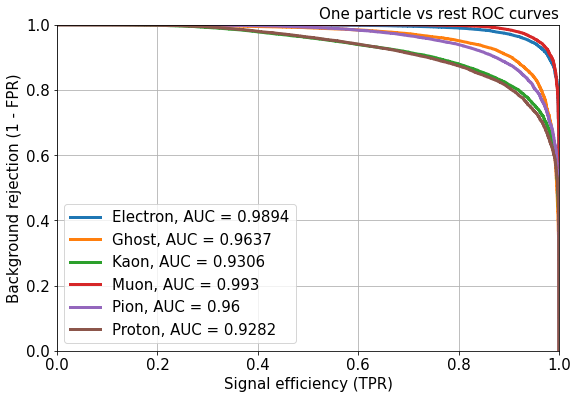

```python
utils.plot_roc_curves(proba, validation_data.Class.values)
```

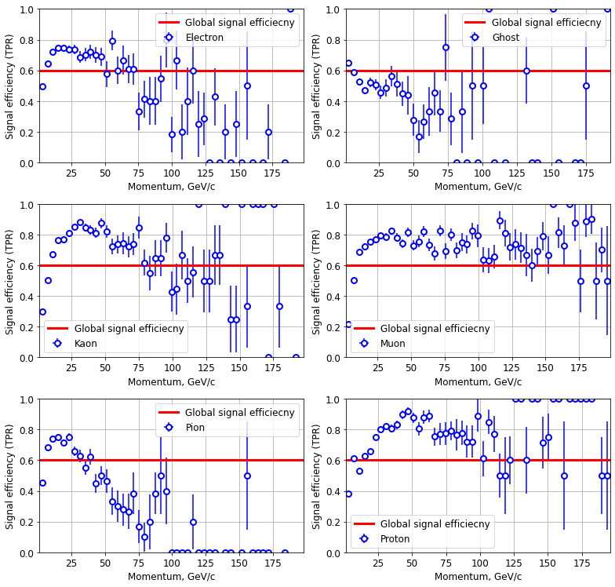

```python
utils.plot_signal_efficiency_on_p(proba, validation_data.Class.values, validation_data.TrackP.values, 60, 50)
plt.show()
```

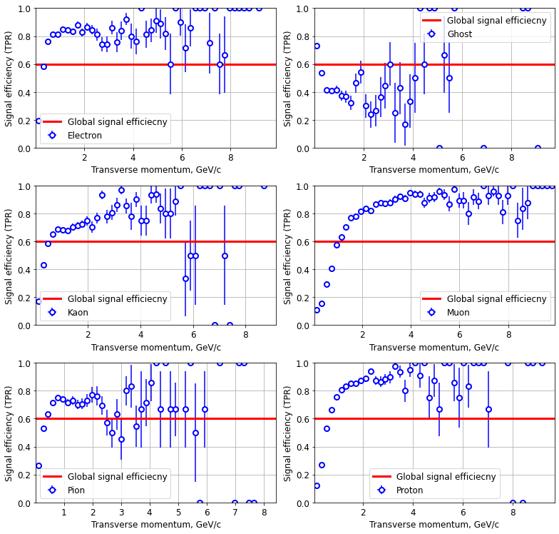

```python
utils.plot_signal_efficiency_on_pt(proba, validation_data.Class.values, validation_data.TrackPt.values, 60, 50)
plt.show()
```